# Analyzing the Stroop Effect

Student: George J.J. Wu  
Date: January 21, 2018

(1) What is the independent variable? What is the dependent variable?

Independent variable: words condition (congruent or incongruent)  
Dependent variable: response time (for participants to name the ink colors, in seconds)

(2) What is an appropriate set of hypotheses for this task? What kind of statistical test do you expect to perform? Justify your choices.

Null hypothesis (Ho): μi - μc ≤ 0,  
the mean response time for the incongruent word condition (μi) should be less than or equal to the mean response time for the congruent word condition (μc).

Alternative hypothesis (Ha): μi - μc > 0,  
the mean response time for the incongruent word condition (μi) should be significantly greater than the mean response time for the congruent word condition (μc).

A one-tailed, dependent samples t-test will be conducted for this analysis, for the following reasons:

- A t-test is chosen because population variance is unknown and the sample size is relatively small (N=24<30).
- A one-tailed test is chosen because the current analysis predicts a direction in which the mean response time should differ between the two word conditions.
- A dependent samples t-test is chosen because the same participants were being measured in both the congruent and incongruent word conditions.

The current analysis makes the following assumptions:

- the dependent variable response time is continuous.
- the participants are independent of one another.
- the distribution of response time is approximately normal.
- the dependent variable response time does not contain any extreme outliers.

(3) Report some descriptive statistics regarding this dataset. Include at least one measure of central tendency and at least one measure of variability. The name of the data file is 'stroopdata.csv'.

```python
# Load data
import pandas as pd
df = pd.read_csv("stroopdata.csv")
```

```python
# Mean response time for congruent condition
df["Congruent"].mean()
```

```
14.051124999999999
```

```python
# Mean response time for incongruent condition
df["Incongruent"].mean()
```

```
22.015916666666666
```

```python
# Standard deviation of response time for congruent condition
df["Congruent"].std()
```

```
3.5593579576451955
```

```python
# Standard deviation of response time for incongruent condition
df["Incongruent"].std()
```

```
4.7970571224691376
```

```python
# Calculate differences in response time between the two word conditions
df["Difference"] = df["Incongruent"] - df["Congruent"]

# Mean difference in response time
df["Difference"].mean()
```

```
7.9647916666666658
```

```python
# Standard deviation of response time differences
df["Difference"].std()
```

```
4.8648269103590556
```

The above descriptive statistics can be summarized in the following table:

| Statistics | Congruent | Incongruent | Difference |
| --- | --- | --- | --- |
| Mean | 14.05 | 22.02 | 7.96 |
| Standard Deviation | 3.56 | 4.80 | 4.86 |

(4) Provide one or two visualizations that show the distribution of the sample data. Write one or two sentences noting what you observe about the plot or plots.

```
Text(0.5,1,'Distribution of Response Time for the Congruent Word Condition')
```

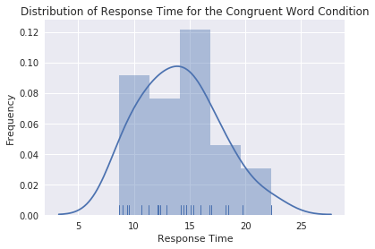

```python
# data visualization libraries
import matplotlib.pyplot as plt
import seaborn as sns

# set style to default
%matplotlib inline
sns.set()

# visualize response time distribution of the congruent word condition
g1 = sns.distplot(df["Congruent"], kde=True, rug=True)
g1.set(xlabel="Response Time", ylabel="Frequency")
plt.title("Distribution of Response Time for the Congruent Word Condition")
```

```
Text(0.5,1,'Distribution of Response Time for the Incongruent Word Condition')
```

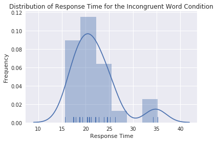

```python
# visualize response time distribution of the incongruent word condition
g2 = sns.distplot(df["Incongruent"], kde=True, rug=True)
g2.set(xlabel="Response Time", ylabel="Frequency")
plt.title("Distribution of Response Time for the Incongruent Word Condition")
```

In both the congruent word condition and the incongruent word condition, the distribution of response time is approximately normal. For the congruent word condition, many responses took around 10 to 20 seconds; whereas for the incongruent word condition, many responses took around 15 to 25 seconds.

(5) Now, perform the statistical test and report the results. What is the confidence level and your critical statistic value? Do you reject the null hypothesis or fail to reject it? Come to a conclusion in terms of the experiment task. Did the results match up with your expectations?

```python
# math library
from math import sqrt

# mean response time difference
mean_diff = df["Difference"].mean()

# standard deviation of response time difference
std_diff = df["Difference"].std()

# sample size
n = df["Difference"].size

# t-statistic
t = mean_diff/(std_diff/(sqrt(n)))

# output t
t
```

```
8.020706944109957
```

Confidence level: 95% (α = .05)  
Degree of freedom: 24 - 1 = 23  
t critical value: 1.714 (one-tailed, according to [t-table](https://s3.amazonaws.com/udacity-hosted-downloads/t-table.jpg))  
t-statistic: 8.0207  
p-value: less than .00001 (according to [GraphPad](https://www.graphpad.com/quickcalcs/pvalue1.cfm))

The t-statistic of 8.0207 is greater than the t critical value of 1.714, indicating that the null hypothesis should be rejected. There is sufficient evidence at 95% level of confidence to suggest that people, on average, take longer time to name ink colors in the incongruent word condition, comparing to their performance in the congruent word condition. This result is indeed congruent with my own expectations.

## Sources

- [Student's t-test](https://en.wikipedia.org/wiki/Student%27s_t-test)
- [Paired Sample T-Test](http://www.statisticssolutions.com/manova-analysis-paired-sample-t-test/)
- [t-table](https://s3.amazonaws.com/udacity-hosted-downloads/t-table.jpg)